# STAT 420 Final Project Proposal

July 17, 2019

# Group Members

- Tao Li (taol4)
- Chun Yue Shek (cyshek2)
- Wanlin Yang (wanliny2)

# Problem

**Predicting House Prices With Linear Regression**

Ask a home buyer to describe their dream house, and they probably won’t begin with the height of the basement ceiling or the proximity to an east-west railroad. But this dataset in our project proves that much more influences price negotiations than the number of bedrooms or a white-picket fence.

We will use 79 explanatory variables describing (almost) every aspect of residential homes in Ames, Iowa, we will try all the techniques learned in this lession to predict the final price of each home.

# Dataset

We will use the [Real Estate Data](https://www.kaggle.com/c/house-prices-advanced-regression-techniques/data) dataset for our final project.

- train.csv - the training set
- test.csv - the test set
- data_description.txt - full description of each column, originally prepared by Dean De Cock but lightly edited to match the column names used here

## Description

This data is the real estate information with publicly available.Features include LotArea (Lot size in square feet), # of Bedroom, and # of Kitchen There are also categorical features, such as GarageType and MSSubClass(Building class), Utilities.

Here’s a brief version of what you’ll find in the data description file.

- SalePrice - the property’s sale price in dollars. This is the target variable that you’re trying to predict.
- MSSubClass: The building class
- MSZoning: The general zoning classification
- LotFrontage: Linear feet of street connected to property
- LotArea: Lot size in square feet
- Street: Type of road access
- Alley: Type of alley access
- LotShape: General shape of property
- LandContour: Flatness of the property
- Utilities: Type of utilities available
- LotConfig: Lot configuration
- LandSlope: Slope of property
- Neighborhood: Physical locations within Ames city limits
- Condition1: Proximity to main road or railroad
- Condition2: Proximity to main road or railroad (if a second is present)
- BldgType: Type of dwelling
- HouseStyle: Style of dwelling
- OverallQual: Overall material and finish quality
- OverallCond: Overall condition rating
- YearBuilt: Original construction date
- YearRemodAdd: Remodel date
- RoofStyle: Type of roof
- RoofMatl: Roof material
- Exterior1st: Exterior covering on house
- Exterior2nd: Exterior covering on house (if more than one material)
- MasVnrType: Masonry veneer type
- MasVnrArea: Masonry veneer area in square feet
- ExterQual: Exterior material quality
- ExterCond: Present condition of the material on the exterior
- Foundation: Type of foundation
- BsmtQual: Height of the basement
- BsmtCond: General condition of the basement
- BsmtExposure: Walkout or garden level basement walls
- BsmtFinType1: Quality of basement finished area
- BsmtFinSF1: Type 1 finished square feet
- BsmtFinType2: Quality of second finished area (if present)
- BsmtFinSF2: Type 2 finished square feet
- BsmtUnfSF: Unfinished square feet of basement area
- TotalBsmtSF: Total square feet of basement area
- Heating: Type of heating
- HeatingQC: Heating quality and condition
- CentralAir: Central air conditioning
- Electrical: Electrical system
- 1stFlrSF: First Floor square feet
- 2ndFlrSF: Second floor square feet
- LowQualFinSF: Low quality finished square feet (all floors)
- GrLivArea: Above grade (ground) living area square feet
- BsmtFullBath: Basement full bathrooms
- BsmtHalfBath: Basement half bathrooms
- FullBath: Full bathrooms above grade
- HalfBath: Half baths above grade
- Bedroom: Number of bedrooms above basement level
- Kitchen: Number of kitchens
- KitchenQual: Kitchen quality
- TotRmsAbvGrd: Total rooms above grade (does not include bathrooms)
- Functional: Home functionality rating
- Fireplaces: Number of fireplaces
- FireplaceQu: Fireplace quality
- GarageType: Garage location
- GarageYrBlt: Year garage was built
- GarageFinish: Interior finish of the garage
- GarageCars: Size of garage in car capacity
- GarageArea: Size of garage in square feet
- GarageQual: Garage quality
- GarageCond: Garage condition
- PavedDrive: Paved driveway
- WoodDeckSF: Wood deck area in square feet
- OpenPorchSF: Open porch area in square feet
- EnclosedPorch: Enclosed porch area in square feet
- 3SsnPorch: Three season porch area in square feet
- ScreenPorch: Screen porch area in square feet
- PoolArea: Pool area in square feet
- PoolQC: Pool quality
- Fence: Fence quality
- MiscFeature: Miscellaneous feature not covered in other categories
- MiscVal: $Value of miscellaneous feature
- MoSold: Month Sold
- YrSold: Year Sold
- SaleType: Type of sale
- SaleCondition: Condition of sale

## Goal

There is a Train, Test dataset. We want to show a cross validated result that with a smallest error inprice? We will try different measures to train your model - RMSE, RMSLE, etc.; however, the accuracy metric is simply mean percent error. We will also perform the feature transofmation and selection to get best model predicting the price.

# Investigation

## Load the data

```r
train = read.csv("train.csv")
str(train)
```

```
## 'data.frame':    1460 obs. of  81 variables:
##  $ Id           : int  1 2 3 4 5 6 7 8 9 10 ...
##  $ MSSubClass   : int  60 20 60 70 60 50 20 60 50 190 ...
##  $ MSZoning     : Factor w/ 5 levels "C (all)","FV",..: 4 4 4 4 4 4 4 4 5 4 ...
##  $ LotFrontage  : int  65 80 68 60 84 85 75 NA 51 50 ...
##  $ LotArea      : int  8450 9600 11250 9550 14260 14115 10084 10382 6120 7420 ...
##  $ Street       : Factor w/ 2 levels "Grvl","Pave": 2 2 2 2 2 2 2 2 2 2 ...
##  $ Alley        : Factor w/ 2 levels "Grvl","Pave": NA NA NA NA NA NA NA NA NA NA ...
##  $ LotShape     : Factor w/ 4 levels "IR1","IR2","IR3",..: 4 4 1 1 1 1 4 1 4 4 ...
##  $ LandContour  : Factor w/ 4 levels "Bnk","HLS","Low",..: 4 4 4 4 4 4 4 4 4 4 ...
##  $ Utilities    : Factor w/ 2 levels "AllPub","NoSeWa": 1 1 1 1 1 1 1 1 1 1 ...
##  $ LotConfig    : Factor w/ 5 levels "Corner","CulDSac",..: 5 3 5 1 3 5 5 1 5 1 ...
##  $ LandSlope    : Factor w/ 3 levels "Gtl","Mod","Sev": 1 1 1 1 1 1 1 1 1 1 ...
##  $ Neighborhood : Factor w/ 25 levels "Blmngtn","Blueste",..: 6 25 6 7 14 12 21 17 18 4 ...
##  $ Condition1   : Factor w/ 9 levels "Artery","Feedr",..: 3 2 3 3 3 3 3 5 1 1 ...
```

[output cut: 67 more lines]

# give the dataset row names, based on id, address

```r
rownames(train) = train$Id
```

## Perform data cleaning

Before we do the analysis and modeling, let’s clean the data by removing the empty values.

```r
train = train[, -which(names(train) %in% c("Id", "Alley", "Utilities", "Condition1", "Condition2","Exterior1st", "Exterior2nd", "FireplaceQu", "PoolQC", "Fence", "MiscFeature"))]
```

```r
train = train[!rowSums(is.na(train)),]
```

# Modeling

## Beta modeling and analysis

```r
mod = lm(SalePrice ~ ., data = train)
summary(mod)
```

```
##
## Call:
## lm(formula = SalePrice ~ ., data = train)
##
## Residuals:
##     Min      1Q  Median      3Q     Max
## -360957  -10397     409   10323  157670
##
## Coefficients: (3 not defined because of singularities)
##                        Estimate Std. Error t value Pr(>|t|)
## (Intercept)          -9.730e+05  1.419e+06  -0.686 0.492936
## MSSubClass           -9.010e+01  1.354e+02  -0.665 0.506003
## MSZoningFV            4.534e+04  1.539e+04   2.947 0.003290 **
## MSZoningRH            3.455e+04  1.659e+04   2.083 0.037551 *
## MSZoningRL            3.094e+04  1.344e+04   2.301 0.021588 *
## MSZoningRM            2.896e+04  1.257e+04   2.304 0.021432 *
## LotFrontage           6.219e+01  5.942e+01   1.047 0.295561
## LotArea               6.319e-01  1.650e-01   3.829 0.000137 ***
## StreetPave            3.301e+04  2.078e+04   1.588 0.112567
## LotShapeIR2           9.587e+03  6.238e+03   1.537 0.124681
## LotShapeIR3           1.513e+04  1.398e+04   1.082 0.279387
## LotShapeReg           2.696e+03  2.214e+03   1.218 0.223631
## LandContourHLS        1.517e+04  6.867e+03   2.209 0.027407 *
## LandContourLow       -9.498e+03  1.067e+04  -0.890 0.373434
## LandContourLvl        1.277e+04  5.118e+03   2.496 0.012730 *
## LotConfigCulDSac      1.382e+04  5.515e+03   2.506 0.012389 *
## LotConfigFR2         -1.324e+04  5.873e+03  -2.254 0.024405 *
## LotConfigFR3         -2.047e+04  1.418e+04  -1.444 0.149020
## LotConfigInside      -1.117e+03  2.447e+03  -0.456 0.648309
## LandSlopeMod          9.251e+03  5.547e+03   1.668 0.095686 .
## LandSlopeSev         -3.044e+04  1.761e+04  -1.728 0.084346 .
## NeighborhoodBlueste   4.256e+03  2.261e+04   0.188 0.850722
## NeighborhoodBrDale    1.022e+04  1.370e+04   0.746 0.455952
## NeighborhoodBrkSide   4.669e+03  1.227e+04   0.380 0.703671
## NeighborhoodClearCr  -6.304e+03  1.297e+04  -0.486 0.627187
## NeighborhoodCollgCr  -6.925e+02  9.327e+03  -0.074 0.940828
## NeighborhoodCrawfor   2.044e+04  1.094e+04   1.869 0.061895 .
## NeighborhoodEdwards  -1.999e+04  1.025e+04  -1.951 0.051374 .
## NeighborhoodGilbert  -5.931e+03  1.004e+04  -0.591 0.554664
## NeighborhoodIDOTRR    8.805e+03  1.413e+04   0.623 0.533487
```

[output cut: 142 more lines]

```
## SaleTypeCWD           8.849e+03  1.534e+04   0.577 0.564263
## SaleTypeNew           1.419e+04  1.948e+04   0.728 0.466506
## SaleTypeOth           2.700e+04  2.738e+04   0.986 0.324449
## SaleTypeWD           -1.889e+03  5.631e+03  -0.335 0.737329
## SaleConditionAdjLand  2.987e+04  2.999e+04   0.996 0.319600
## SaleConditionAlloca   1.204e+04  1.395e+04   0.863 0.388135
## SaleConditionFamily  -1.370e+03  7.686e+03  -0.178 0.858620
## SaleConditionNormal   5.832e+03  3.892e+03   1.499 0.134336
## SaleConditionPartial  3.768e+02  1.877e+04   0.020 0.983987
## ---
## Signif. codes:  0 '***' 0.001 '**' 0.01 '*' 0.05 '.' 0.1 ' ' 1
##
## Residual standard error: 26340 on 916 degrees of freedom
## Multiple R-squared:  0.916,  Adjusted R-squared:  0.8997
## F-statistic:  56.4 on 177 and 916 DF,  p-value: < 2.2e-16
```

```r
(mod_aic_back = step(mod, trace = 0))
```

```
##
## Call:
## lm(formula = SalePrice ~ MSSubClass + MSZoning + LotArea + Street +
##     LotShape + LandContour + LotConfig + LandSlope + Neighborhood +
##     BldgType + OverallQual + OverallCond + YearBuilt + RoofMatl +
##     ExterQual + BsmtQual + BsmtExposure + BsmtFinSF1 + BsmtFinSF2 +
##     BsmtUnfSF + X1stFlrSF + X2ndFlrSF + FullBath + BedroomAbvGr +
##     KitchenAbvGr + KitchenQual + TotRmsAbvGrd + Fireplaces +
##     GarageYrBlt + GarageCars + ScreenPorch + PoolArea + SaleCondition,
##     data = train)
##
## Coefficients:
##          (Intercept)            MSSubClass            MSZoningFV
##           -1.492e+06            -1.332e+02             3.955e+04
##           MSZoningRH            MSZoningRL            MSZoningRM
##            2.883e+04             2.830e+04             2.370e+04
##              LotArea            StreetPave           LotShapeIR2
##            6.842e-01             3.006e+04             1.186e+04
##          LotShapeIR3           LotShapeReg        LandContourHLS
##            1.773e+04             2.207e+03             1.769e+04
##       LandContourLow        LandContourLvl      LotConfigCulDSac
##           -9.148e+03             1.358e+04             1.034e+04
##         LotConfigFR2          LotConfigFR3       LotConfigInside
##           -1.406e+04            -1.904e+04            -2.373e+03
##         LandSlopeMod          LandSlopeSev   NeighborhoodBlueste
##            6.698e+03            -3.822e+04             7.448e+03
##   NeighborhoodBrDale   NeighborhoodBrkSide   NeighborhoodClearCr
##            9.532e+03             5.462e+03            -6.281e+03
##  NeighborhoodCollgCr   NeighborhoodCrawfor   NeighborhoodEdwards
##            2.662e+03             2.301e+04            -1.580e+04
##  NeighborhoodGilbert    NeighborhoodIDOTRR   NeighborhoodMeadowV
##           -4.503e+03             1.021e+04             4.629e+03
##  NeighborhoodMitchel     NeighborhoodNAmes   NeighborhoodNoRidge
##           -1.251e+04            -7.154e+03             4.893e+04
##  NeighborhoodNPkVill   NeighborhoodNridgHt    NeighborhoodNWAmes
##            5.744e+03             3.183e+04            -1.388e+04
##  NeighborhoodOldTown    NeighborhoodSawyer   NeighborhoodSawyerW
##           -3.510e+03            -4.030e+03             4.052e+03
##  NeighborhoodSomerst   NeighborhoodStoneBr     NeighborhoodSWISU
##            1.226e+04             5.371e+04             2.103e+03
```

[output cut: 17 more lines]

```
##            4.265e+01             2.911e+01             2.459e+01
##            X1stFlrSF             X2ndFlrSF              FullBath
##            3.900e+01             5.218e+01             4.911e+03
##         BedroomAbvGr          KitchenAbvGr         KitchenQualFa
##           -4.239e+03            -2.431e+04            -2.175e+04
##        KitchenQualGd         KitchenQualTA          TotRmsAbvGrd
##           -2.523e+04            -2.473e+04             2.673e+03
##           Fireplaces           GarageYrBlt            GarageCars
##            4.026e+03             9.699e+01             8.510e+03
##          ScreenPorch              PoolArea  SaleConditionAdjLand
##            2.835e+01             8.810e+01             2.831e+04
##  SaleConditionAlloca   SaleConditionFamily   SaleConditionNormal
##            1.748e+04            -3.201e+03             4.172e+03
## SaleConditionPartial
##            1.464e+04
```

```r
length(coef(mod_aic_back))
```

```
## [1] 88
```

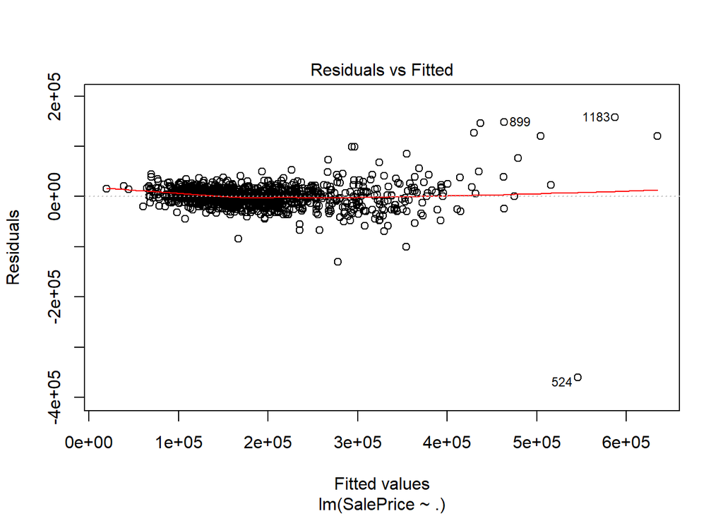

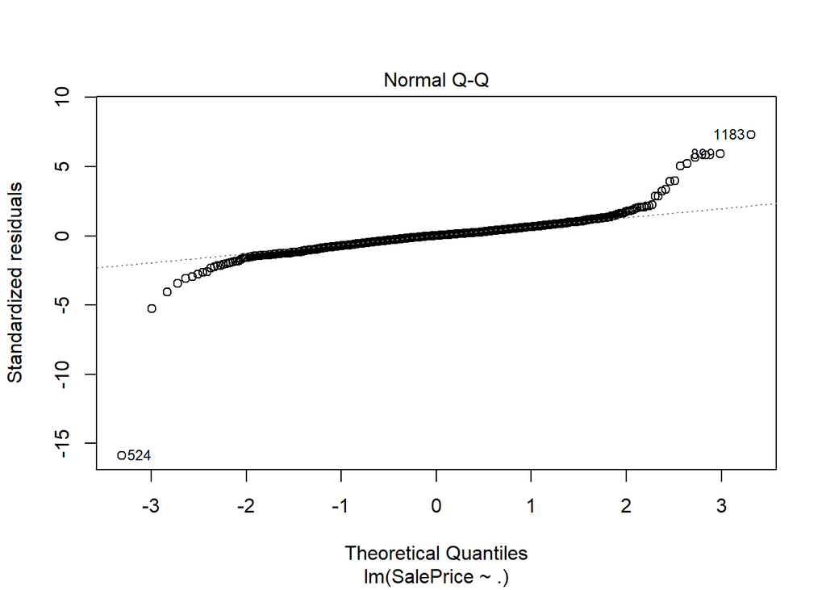

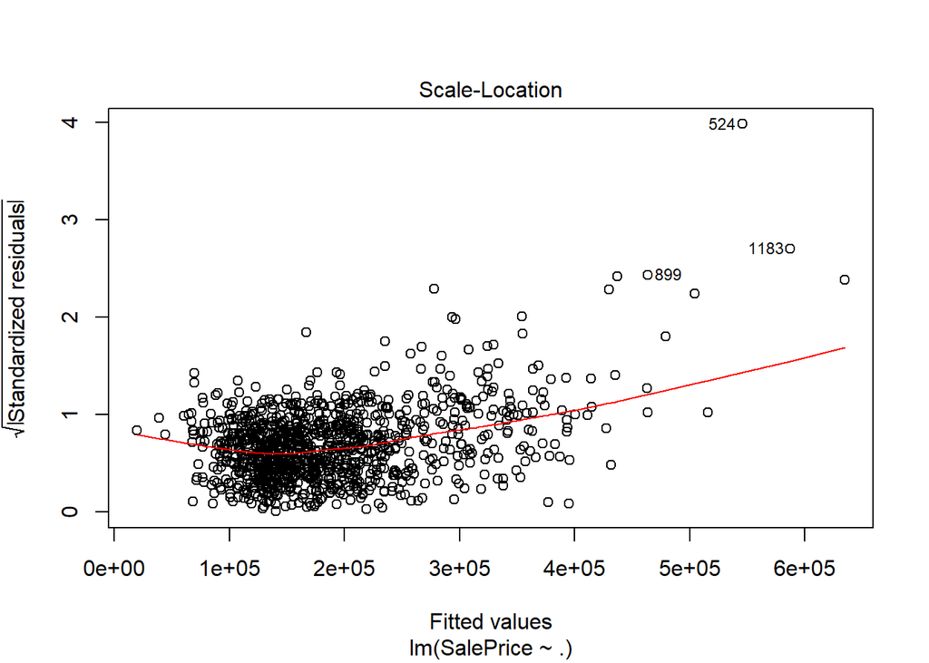

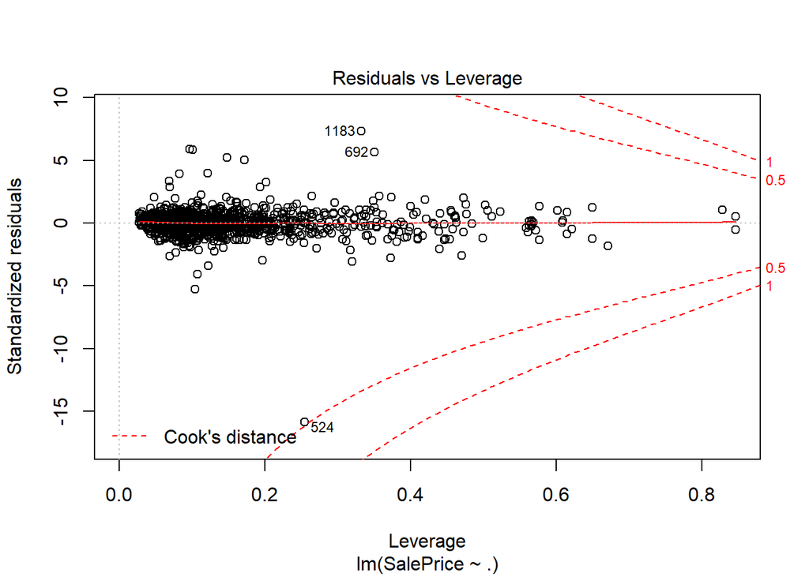

```r
#plot(train)
plot(mod)
```

Based on the analysis, it’s clear to see

- The beta model can fit the data with these selected predictors.
- It’s not enough to achieve a good enough model. We will continue the analysis and try advanced modeling techniques in the project.

## Proposed approach

We will firstly implement the model with all 79 predictors and analyse its metrics. But using all 79 predictors seems too much, so we need to investigate the correlation between predictors and pick a suitable combination of predictors to make the model robust. For example, we can find the best model for 10 predictors, 20 predictors, 40 predictors separately, and compare their performance with the one that uses all predictors.

## Further analysis

It will be applealing that the model will work for house in real life rather than only test data. We may apply the model over the houses we have known around us, and analyse whether there can be some potential influence to the house price that cannot be reflected by data.